# Eye cancer outcome classification

DA5030 CRISP-DM course project and evaluation audit

Sucharita Roy

## 1 Business understanding and study scope

This course project compares methods for classifying the recorded status of eye cancer cases as Active, In Remission, or Deceased. The business question is whether baseline characteristics in this teaching dataset contain enough signal to classify those statuses better than a simple baseline. The practical output is a comparison of algorithms and ensembles, with reproducible evaluation and explicit limitations. There is no clinical deployment in this project.

The dataset was obtained from the Kaggle Eye Cancer Patient Records listing: https://www.kaggle.com/datasets/ak0212/eye-cancer-patient-records. The original course analysis describes the data as simulated. I therefore treat it as a simulated teaching dataset; provenance and license terms should be confirmed at the source before reuse outside this exercise. It is not an independently validated clinical cohort. Dataset approval was a course requirement; this repository does not independently establish that approval was received.

I exclude survival duration and treatment variables. Their availability at a prediction time is not established, so retaining them would make a prospective interpretation difficult to defend. Even the retained features do not establish a valid clinical prediction timeline. This remains a retrospective teaching exercise, not a prognosis tool.

## 2 Data understanding and quality assessment

```r
raw <- read_project_data(root)
x <- make_predictors(raw)
y <- raw$Outcome_Status
quality <- data.frame(
  Field = names(raw),
  Missing = vapply(raw, function(v) sum(is.na(v)), integer(1)),
  Unique = vapply(raw, function(v) length(unique(v)), integer(1))
)
knitr::kable(quality)
```

|  | Field | Missing | Unique |
| --- | --- | --- | --- |
| Patient_ID | Patient_ID | 0 | 5000 |
| Age | Age | 0 | 90 |
| Gender | Gender | 0 | 3 |
| Cancer_Type | Cancer_Type | 0 | 3 |
| Laterality | Laterality | 0 | 3 |
| Date_of_Diagnosis | Date_of_Diagnosis | 0 | 1957 |
| Stage_at_Diagnosis | Stage_at_Diagnosis | 0 | 4 |
| Treatment_Type | Treatment_Type | 0 | 3 |
| Surgery_Status | Surgery_Status | 0 | 2 |
| Radiation_Therapy | Radiation_Therapy | 0 | 71 |
| Chemotherapy | Chemotherapy | 0 | 21 |
| Outcome_Status | Outcome_Status | 0 | 3 |
| Survival_Time_Months | Survival_Time_Months | 0 | 120 |
| Genetic_Markers | Genetic_Markers | 0 | 2 |
| Family_History | Family_History | 0 | 2 |
| Country | Country | 0 | 10 |

There are 5000 records. IDs must be unique, outcome labels must be present and recognized, and nonmissing ages must be positive and finite. The pipeline stops on violations instead of silently deleting cases. Missing numeric predictors are median-imputed using training rows. Missing categorical values receive a separate category. The literal marker value “None” is retained as a recorded category; interpreting it as an absent test, an absent mutation, or a missing result would require a data dictionary. I do not assume these meanings are interchangeable. No outlier clipping is applied without a defensible domain threshold.

## 3 Split strategy and training-only exploration

All algorithms use the same stratified 70/30 outer split. The split and fold assignments are saved with patient IDs. Five stratified folds within the training partition are used for tuning; a smoke run uses three folds on a small subset. The test partition is reserved for final comparisons. Preprocessing is refitted inside each fold and each bootstrap sample.

```r
train_idx <- stratified_split(y)
train_x <- x[train_idx, , drop = FALSE]
train_y <- y[train_idx]
folds <- make_folds(train_y, k = 5L)
knitr::kable(as.data.frame(table(train_y)), col.names = c("Training outcome", "Count"))
```

| Training outcome | Count |
| --- | --- |
| Active | 1130 |
| Deceased | 1197 |
| In.Remission | 1172 |

```r
summary(train_x$Age)
```

```
##    Min. 1st Qu.  Median    Mean 3rd Qu.    Max.
##    1.00   23.00   44.00   45.08   68.00   90.00
```

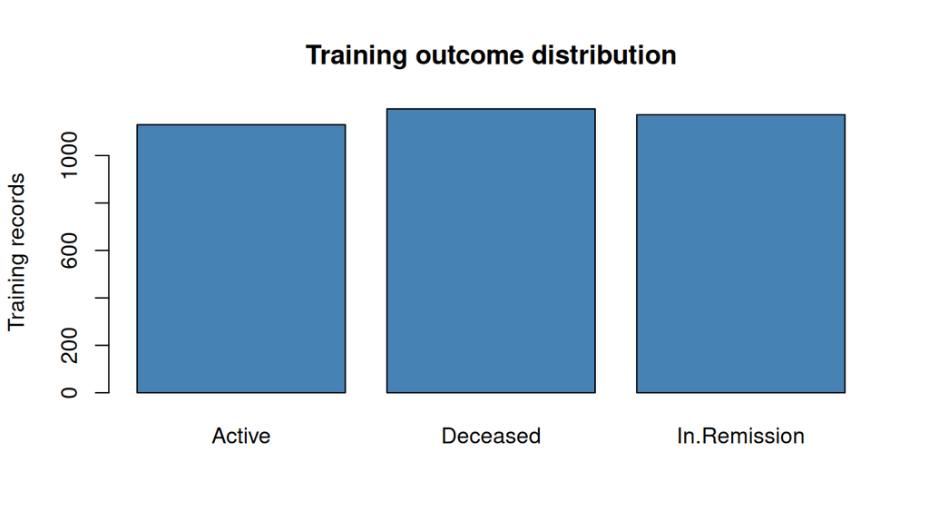

```r
barplot(table(train_y), ylab = "Training records", col = "steelblue",
        main = "Training outcome distribution")
```

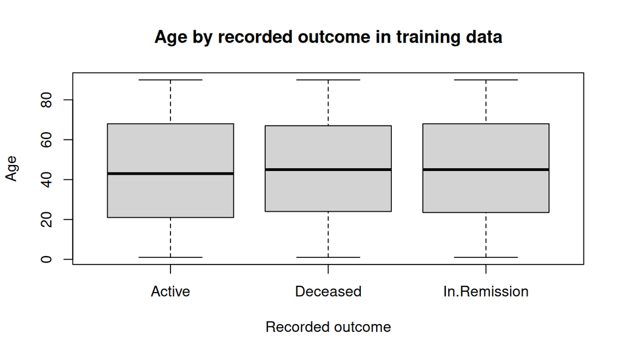

```r
boxplot(train_x$Age ~ train_y, xlab = "Recorded outcome", ylab = "Age",
        main = "Age by recorded outcome in training data", col = "lightgray")
```

These plots describe this training sample. They do not establish causal effects, clinical representativeness, or predictive usefulness. Model comparisons below provide the relevant predictive evidence.

## 4 Model-specific data shaping

The predictors include age, an age-group transformation with fixed cutoffs, gender, cancer type, laterality, stage, genetic-marker category, family history, and country. IDs, diagnosis dates, survival duration, and treatment variables are excluded. Country and other demographic fields can reflect sampling or social context; this exercise does not establish fairness across subgroups.

| Algorithm | Input representation | Reason |
| --- | --- | --- |
| Regularized multinomial logistic regression | One-hot categories and standardized numeric matrix | Numeric design matrix; scaling makes the decay penalty more comparable across columns |
| kNN | The same standardized encoded matrix | Euclidean distances require numeric inputs and comparable scales |
| Random forest | Imputed numeric columns and categorical factors | Native factor handling avoids imposing an arbitrary integer order |
| XGBoost | One-hot numeric matrix without scaling | Numeric inputs are required; tree splits do not need standardization |

I use `nnet::multinom` with tuned decay for the logistic model. This replaces the previous mix of glmnet for one fit and an unpenalized multinomial fit for bagging, so the base learner and its bagged version now use the same modeling procedure. I remove the earlier PCA transformation: it was fitted before splitting, and PCA is not required for this modest feature set. Zero-variance encoded columns are removed based on fit rows only. kNN retains the encoded categorical predictors rather than accidentally dropping them.

```r
prep <- fit_preprocessor(train_x)
lr_matrix <- transform_predictors(prep, train_x, "lr")
rf_frame <- transform_predictors(prep, train_x, "rf")
xgb_matrix <- transform_predictors(prep, train_x, "xgb")
data.frame(Representation = c("Scaled encoded", "Native factors", "Unscaled encoded"),
           Rows = c(nrow(lr_matrix), nrow(rf_frame), nrow(xgb_matrix)),
           Columns = c(ncol(lr_matrix), ncol(rf_frame), ncol(xgb_matrix)))
```

```
##     Representation Rows Columns
## 1   Scaled encoded 3499      31
## 2   Native factors 3499       9
## 3 Unscaled encoded 3499      31
```

The example above fits on the outer training data for illustration. Tuning does **not** reuse that preprocessor: every fold learns its own imputation, category mapping, zero-variance filter, and scaling using only that fold’s training rows. Previously unseen categorical values map to a novel category. Dummy columns constant in fit rows are removed; unseen categories consequently contribute no learned category-specific coefficient.

## 5 Model fitting and hyperparameter tuning

Random forests use a fixed minimum terminal-node size of 10 and a maximum of 64 terminal nodes per tree to limit tree complexity and keep repeated bootstrap runs practical. These limits are fixed before held-out evaluation.

The four algorithms cover linear decision boundaries, local similarity, bagged trees, and boosted trees. XGBoost supplies the boosting component. Each tuning candidate is compared using mean macro-F1 across the same training folds. A single fixed seed schedule makes comparisons reproducible. Grid ties select the first listed candidate; test performance does not choose hyperparameters.

```r
model_grids(smoke = params$smoke)
```

```
## $lr
##   decay
## 1  0.01
## 2  0.10
## 3  1.00
##
## $knn
##    k
## 1  5
## 2 15
## 3 35
##
## $rf
##   mtry ntree
## 1    2   300
## 2    4   300
## 3    7   300
##
## $xgb
##   max_depth  eta nrounds
## 1         2 0.05     100
## 2         4 0.05     100
## 3         2 0.10     100
## 4         4 0.10     100
```

```r
function (kind, x, y, folds, grid, seed = 1000)
{
    classes <- levels(y)
    scores <- matrix(NA_real_, nrow(grid), max(folds))
    predictions <- vector("list", nrow(grid))
    for (g in seq_len(nrow(grid))) {
        oof <- matrix(NA_real_, nrow(x), length(classes), dimnames = list(NULL,
            classes))
        for (f in sort(unique(folds))) {
            validation <- which(folds == f)
            fit <- which(folds != f)
            p <- fit_predict(kind, x[fit, , drop = FALSE], y[fit],
                x[validation, , drop = FALSE], as.list(grid[g,
                  , drop = FALSE]), seed + f)
            oof[validation, ] <- p
            scores[g, f] <- score_predictions(y[validation],
                probability_labels(p), classes)$summary[["Macro_F1"]]
        }
        predictions[[g]] <- oof
    }
    mean_scores <- rowMeans(scores)
    best <- which.max(mean_scores)
    list(params = as.list(grid[best, , drop = FALSE]), oof = predictions[[best]],
        table = cbind(grid, CV_Macro_F1 = mean_scores, CV_SD = apply(scores,
            1, sd)), best_row = best)
}
```

```r
function (kind, x, y, param, seed)
{
    set.seed(seed)
    if (kind == "lr") {
        model <- nnet::multinom(y ~ ., data = data.frame(y = y,
            x, check.names = TRUE), decay = param$decay, maxit = 1000,
            MaxNWts = 1e+05, trace = FALSE)
        if (model$convergence != 0)
            stop("Logistic regression did not converge.")
        return(model)
    }
    if (kind == "knn")
        return(list(x = x, y = y, k = param$k))
    if (kind == "rf")
        return(randomForest::randomForest(x = x, y = y, ntree = param$ntree,
            mtry = min(param$mtry, ncol(x)), nodesize = 10L,
            maxnodes = 64L))
    if (kind == "xgb")
        return(xgboost::xgboost(data = x, label = as.integer(y) -
            1L, objective = "multi:softprob", num_class = nlevels(y),
            nrounds = param$nrounds, max_depth = param$max_depth,
            eta = param$eta, subsample = 0.8, colsample_bytree = 0.8,
            nthread = 1, eval_metric = "mlogloss", verbose = 0))
    stop("Unknown model.")
}
```

## 6 Homogeneous and heterogeneous ensembles

For each algorithm, I fit stratified bootstrap replicas with replacement and average their class probabilities. This is a homogeneous ensemble because every replica uses the same algorithm. The full run uses 30 replicas per algorithm; the smoke test uses two. Random forest already uses bootstrap trees internally; outer bagging of forests is included to make the assignment’s per-algorithm bagging requirement explicit. Bagging XGBoost also is additional to boosting, not a replacement for it. These extra fits are not presumed to improve results.

```r
function (kind, x, y, new_x, param, bags = 30L, seed = 3000)
{
    total <- matrix(0, nrow(new_x), nlevels(y), dimnames = list(NULL,
        levels(y)))
    for (b in seq_len(bags)) {
        set.seed(seed + b)
        idx <- unlist(lapply(split(seq_along(y), y), function(rows) sample(rows,
            length(rows), replace = TRUE)), use.names = FALSE)
        total <- total + fit_predict(kind, x[idx, , drop = FALSE],
            y[idx], new_x, param, seed + 10000 + b)
    }
    total/bags
}
```

The heterogeneous soft-voting ensemble averages probabilities from the four bagged learners with equal weights fixed in advance. It combines different algorithms as required. I also evaluate a separate stacked ensemble built from the four unbagged learners. Its meta-model is trained on out-of-fold predictions from training patients only. Each such prediction comes from a base fit that excluded that patient’s fold. The final base fits then predict the held-out test patients, and the meta-model combines those predictions. The test labels are never used to train the stack.

The following excerpt shows the training/evaluation boundary inside the runner; `oof` contains training-only predictions, and `base_probs` contains held-out predictions. The complete implementation is in `src/ml_pipeline.R`.

```r
meta_train <- data.frame(Outcome_Status = train_y, meta_features(oof))
meta_model <- nnet::multinom(Outcome_Status ~ ., data = meta_train,
                            decay = 1, maxit = 1000, trace = FALSE)
stack_probs <- predict(meta_model, newdata = meta_features(base_probs), type = "probs")
vote_probs <- Reduce("+", bagged_probs) / length(bagged_probs)
```

OOF predictions use hyperparameters chosen within the outer training partition. Their training scores are not claimed as unbiased estimates after that selection. The outer held-out test provides the final comparison. The stack’s decay is fixed at 1 rather than chosen by checking test performance.

## 7 Run the experiment and evaluate

```r
if (params$rerun) {
  result <- run_experiment(raw, outdir, smoke = params$smoke)
} else {
  status <- file.path(outdir, "run_status.txt")
  if (!file.exists(status) || !identical(readLines(status), "COMPLETE"))
    stop("No complete run found; render with rerun = TRUE.")
  config <- dget(file.path(outdir, "run_config.R"))
  if (!identical(config$data_md5,
                 unname(tools::md5sum(file.path(root, "data", "eye_cancer_patients.csv")))) ||
      !identical(config$code_md5, unname(tools::md5sum(file.path(root, "src", "ml_pipeline.R")))))
    stop("Data or analysis code changed; rerun the experiment.")
  result <- readRDS(file.path(outdir, "analysis.rds"))
  result$comparison <- result$metrics
}
knitr::kable(result$comparison, digits = 3)
```

| Model | Accuracy | Macro_F1 | Macro_Precision | Macro_Recall | Mode |
| --- | --- | --- | --- | --- | --- |
| Majority baseline | 0.342 | 0.170 | 0.114 | 0.333 | full |
| Stratified random baseline | 0.342 | 0.342 | 0.342 | 0.342 | full |
| Logistic regression | 0.336 | 0.331 | 0.336 | 0.334 | full |
| kNN | 0.320 | 0.319 | 0.320 | 0.320 | full |
| Random forest | 0.343 | 0.332 | 0.337 | 0.341 | full |
| XGBoost | 0.332 | 0.331 | 0.332 | 0.332 | full |
| Bagged Logistic regression | 0.327 | 0.322 | 0.326 | 0.325 | full |
| Bagged kNN | 0.318 | 0.316 | 0.317 | 0.317 | full |
| Bagged Random forest | 0.349 | 0.340 | 0.345 | 0.347 | full |
| Bagged XGBoost | 0.322 | 0.320 | 0.321 | 0.321 | full |
| Heterogeneous soft vote | 0.324 | 0.319 | 0.321 | 0.322 | full |
| OOF stacked ensemble | 0.320 | 0.252 | 0.261 | 0.314 | full |

**Run mode: full.** These are results from the full dataset with the fixed held-out split.

Macro-F1 gives every class equal weight. Accuracy, macro precision, macro recall, per-class results, and confusion matrices provide complementary views. A class with no predicted positives receives precision and F1 of zero rather than being silently omitted. The majority baseline is chosen from training counts. A second baseline samples labels using training class proportions with a fixed seed; it represents a classifier with no patient-specific signal. Baseline macro-F1 need not equal 1/3; the pipeline computes it from actual predictions.

```r
function (truth, pred, classes = levels(truth))
{
    cm <- table(factor(truth, levels = classes), factor(pred,
        levels = classes))
    tp <- diag(cm)
    divide <- function(a, b) ifelse(b == 0, 0, a/b)
    precision <- divide(tp, colSums(cm))
    recall <- divide(tp, rowSums(cm))
    f1 <- divide(2 * tp, rowSums(cm) + colSums(cm))
    list(summary = c(Accuracy = sum(tp)/sum(cm), Macro_F1 = mean(f1),
        Macro_Precision = mean(precision), Macro_Recall = mean(recall)),
        per_class = data.frame(Class = classes, Precision = precision,
            Recall = recall, F1 = f1, Support = rowSums(cm)),
        confusion = cm)
}
```

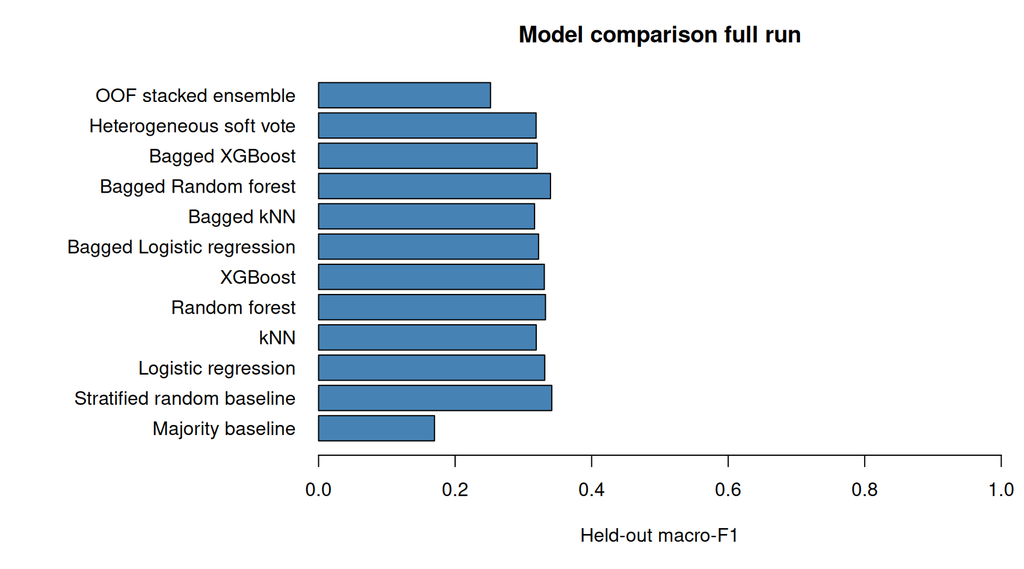

```r
comparison <- result$comparison
par(mar = c(5, 14, 3, 1))
barplot(comparison$Macro_F1, names.arg = comparison$Model, horiz = TRUE,
        las = 1, xlim = c(0, 1), xlab = "Held-out macro-F1", col = "steelblue",
        main = paste("Model comparison", mode, "run"))
```

```r
knitr::kable(result$per_class, digits = 3, row.names = FALSE)
```

| Model | Class | Precision | Recall | F1 | Support |
| --- | --- | --- | --- | --- | --- |
| Majority baseline | Active | 0.000 | 0.000 | 0.000 | 485 |
| Majority baseline | Deceased | 0.342 | 1.000 | 0.509 | 513 |
| Majority baseline | In.Remission | 0.000 | 0.000 | 0.000 | 503 |
| Stratified random baseline | Active | 0.316 | 0.305 | 0.311 | 485 |
| Stratified random baseline | Deceased | 0.367 | 0.370 | 0.369 | 513 |
| Stratified random baseline | In.Remission | 0.342 | 0.350 | 0.346 | 503 |
| Logistic regression | Active | 0.338 | 0.243 | 0.283 | 485 |
| Logistic regression | Deceased | 0.333 | 0.407 | 0.366 | 513 |
| Logistic regression | In.Remission | 0.338 | 0.352 | 0.345 | 503 |
| kNN | Active | 0.315 | 0.324 | 0.319 | 485 |
| kNN | Deceased | 0.321 | 0.357 | 0.338 | 513 |
| kNN | In.Remission | 0.324 | 0.278 | 0.299 | 503 |
| Random forest | Active | 0.310 | 0.198 | 0.242 | 485 |
| Random forest | Deceased | 0.362 | 0.466 | 0.408 | 513 |
| Random forest | In.Remission | 0.339 | 0.358 | 0.348 | 503 |
| XGBoost | Active | 0.324 | 0.276 | 0.298 | 485 |
| XGBoost | Deceased | 0.336 | 0.372 | 0.353 | 513 |
| XGBoost | In.Remission | 0.336 | 0.346 | 0.341 | 503 |
| Bagged Logistic regression | Active | 0.317 | 0.231 | 0.267 | 485 |
| Bagged Logistic regression | Deceased | 0.337 | 0.400 | 0.366 | 513 |
| Bagged Logistic regression | In.Remission | 0.322 | 0.346 | 0.334 | 503 |
| Bagged kNN | Active | 0.304 | 0.266 | 0.284 | 485 |
| Bagged kNN | Deceased | 0.313 | 0.337 | 0.325 | 513 |
| Bagged kNN | In.Remission | 0.334 | 0.348 | 0.341 | 503 |
| Bagged Random forest | Active | 0.322 | 0.219 | 0.260 | 485 |
| Bagged Random forest | Deceased | 0.361 | 0.476 | 0.411 | 513 |
| Bagged Random forest | In.Remission | 0.350 | 0.346 | 0.348 | 503 |
| Bagged XGBoost | Active | 0.301 | 0.260 | 0.279 | 485 |
| Bagged XGBoost | Deceased | 0.345 | 0.370 | 0.357 | 513 |
| Bagged XGBoost | In.Remission | 0.316 | 0.334 | 0.325 | 503 |
| Heterogeneous soft vote | Active | 0.303 | 0.223 | 0.257 | 485 |
| Heterogeneous soft vote | Deceased | 0.331 | 0.390 | 0.358 | 513 |
| Heterogeneous soft vote | In.Remission | 0.330 | 0.354 | 0.341 | 503 |
| OOF stacked ensemble | Active | 0.138 | 0.008 | 0.016 | 485 |
| OOF stacked ensemble | Deceased | 0.325 | 0.632 | 0.429 | 513 |
| OOF stacked ensemble | In.Remission | 0.321 | 0.302 | 0.311 | 503 |

```r
confusions <- if (!is.null(result$confusion)) result$confusion else lapply(result$scored, `[[`, "confusion")
confusions
```

```
## $`Majority baseline`
##
##                Active Deceased In.Remission
##   Active            0      485            0
##   Deceased          0      513            0
##   In.Remission      0      503            0
##
## $`Stratified random baseline`
##
##                Active Deceased In.Remission
##   Active          148      159          178
##   Deceased        162      190          161
##   In.Remission    158      169          176
##
## $`Logistic regression`
##
##                Active Deceased In.Remission
##   Active          118      196          171
##   Deceased        128      209          176
##   In.Remission    103      223          177
##
## $kNN
##
##                Active Deceased In.Remission
##   Active          157      193          135
##   Deceased        173      183          157
##   In.Remission    169      194          140
##
## $`Random forest`
##
##                Active Deceased In.Remission
##   Active           96      203          186
##   Deceased        109      239          165
##   In.Remission    105      218          180
##
## $XGBoost
##
##                Active Deceased In.Remission
##   Active          134      184          167
##   Deceased        145      191          177
```

[output cut: 28 more lines]

```
##   In.Remission    143      192          168
##
## $`Heterogeneous soft vote`
##
##                Active Deceased In.Remission
##   Active          108      193          184
##   Deceased        135      200          178
##   In.Remission    114      211          178
##
## $`OOF stacked ensemble`
##
##                Active Deceased In.Remission
##   Active            4      335          146
##   Deceased         13      324          176
##   In.Remission     12      339          152
```

## 8 Interpretation and limitations

```r
best <- comparison[which.max(comparison$Macro_F1), ]
baseline <- comparison$Macro_F1[comparison$Model == "Majority baseline"]
cat(sprintf("The largest observed macro-F1 in this %s run is **%.3f** for **%s**. Its difference from the majority baseline is **%+.3f**.\n\n",
            mode, best$Macro_F1, best$Model, best$Macro_F1 - baseline))
```

The largest observed macro-F1 in this full run is **0.342** for **Stratified random baseline**. Its difference from the majority baseline is **+0.172**.

```r
random_baseline <- comparison$Macro_F1[comparison$Model == "Stratified random baseline"]
cat(sprintf("The stratified random baseline scored %.3f; the best observed score differs from it by %+.3f.\n\n", random_baseline, best$Macro_F1 - random_baseline))
```

The stratified random baseline scored 0.342; the best observed score differs from it by +0.000.

```r
cat("This is a descriptive comparison on one fixed split. It does not establish statistical superiority, clinical usefulness, or generalization to other patients. Selecting the largest test score is not permission to retune on that test set.\n\n")
```

This is a descriptive comparison on one fixed split. It does not establish statistical superiority, clinical usefulness, or generalization to other patients. Selecting the largest test score is not permission to retune on that test set.

```r
for (kind in names(result$tuning)) {
  z <- result$tuning[[kind]]
  selected <- z$table[z$best_row, , drop = FALSE]
  cat(sprintf("For **%s**, the selected training-CV mean macro-F1 was %.3f. The grid and its fold-to-fold SD are saved in `tuning_%s.csv`.\n\n",
              kind, selected$CV_Macro_F1, kind))
}
```

For **lr**, the selected training-CV mean macro-F1 was 0.320. The grid and its fold-to-fold SD are saved in `tuning_lr.csv`.

For **knn**, the selected training-CV mean macro-F1 was 0.326. The grid and its fold-to-fold SD are saved in `tuning_knn.csv`.

For **rf**, the selected training-CV mean macro-F1 was 0.315. The grid and its fold-to-fold SD are saved in `tuning_rf.csv`.

For **xgb**, the selected training-CV mean macro-F1 was 0.330. The grid and its fold-to-fold SD are saved in `tuning_xgb.csv`.

The simulated data and uncertain timing of outcome assessment limit interpretation. A modest score is a useful result when reported honestly; it does not by itself prove that the implementation is correct or that the features lack signal. The regression tests, saved predictions, and reproducible commands are separate checks on correctness. No claim is made that stacking or bagging must improve over individual models. There is no external validation, calibrated clinical risk estimate, subgroup fairness assessment, or evidence of deployment readiness. Future work would require a clearly timed prediction target and an appropriate independent cohort, not simply a larger ensemble.

## 9 Reproducibility and assignment coverage

The complete implementation is in `src/ml_pipeline.R`; the notebook displays the main fitting, tuning, bagging, and scoring code alongside the explanations. The command-line entry point executes the same implementation. CSV files record split assignments, tuning grids, predictions, class probabilities, and metrics. `run_status.txt` must say COMPLETE before outputs are interpreted as a finished run. `sessionInfo.txt` records actual package versions and `run_config.R` records seeds, settings, data and code fingerprints. Fitted models are not deployed.

| Assignment component | Evidence |
| --- | --- |
| Dataset approval | Must be confirmed from course records; not inferred here |
| At least three algorithms and separate shaping | Four learners and explicit representations |
| Boosting and tuning | XGBoost plus training-only CV grids |
| Bagging and homogeneous ensembles | Bootstrap ensembles for all four learners |
| CRISP-DM and journal | Question, data audit, preparation, modeling, evaluation, limitations |
| Heterogeneous ensemble | Equal-weight soft voting and OOF stacking |
| Metrics and interpretation | Common held-out split, baseline, class metrics and dynamic report |

[session information not shown]